# Linear Regression: Model Specification, Comparison, and Interpretation

- Show All Code
- Hide All Code
- View Source

A worked example using occupational prestige

Author

Graduate Statistics — Demonstration

## Purpose

This report demonstrates a complete linear regression workflow:

**Explore Data → Specify Models → Estimate Models → Compare Models → Evaluate Assumptions → Select a Model → Interpret Results**

We will use the `carData::Prestige` dataset to investigate associations between occupational prestige, education, income, and occupational category.

Our objectives are to:

1. Specify and estimate several plausible competing regression models.
2. Compare nested models using F-tests and changes in explained variance.
3. Evaluate overall model performance using R², adjusted R², and RMSE.
4. Examine regression diagnostics.
5. Select and interpret a preferred model.
6. Report results reproducibly using Quarto.

All numerical results in this document are generated directly from the analysis.

## 1. Load packages and prepare the data

Install any missing packages **once in the R Console**:

```r
install.packages(c(
  "carData", "dplyr", "tidyr", "ggplot2",
  "broom", "performance", "gt"
))
```

The following code belongs in the Quarto document.

```r
library(carData)
library(dplyr)
library(tidyr)
library(ggplot2)
library(broom)
library(performance)
library(gt)

# Keep the same complete-case sample for every model
dat <- Prestige |>
  select(prestige, education, income, type) |>
  drop_na() |>
  mutate(type = factor(type))

n <- nrow(dat)
```

The dataset contains occupational prestige scores, average education, average income, and occupational categories.

We use complete cases for all variables so that the candidate models are estimated using the same observations.

The final analysis includes **98 occupations**.

### Research question and predictions

How are education, income, and occupational category associated with occupational prestige?

We expect:

- Occupations requiring more education to have higher prestige.
- Occupations with higher average incomes to have higher prestige.
- Occupational category to explain additional variation in prestige beyond education and income.

These are predictions about associations, not causal effects.

## 2. Explore the data

### Descriptive statistics

```r
descriptives <- dat |>
  summarise(
    across(
      c(prestige, education, income),
      list(mean = mean, sd = sd, min = min, max = max)
    )
  ) |>
  pivot_longer(
    everything(),
    names_to = c("variable", ".value"),
    names_sep = "_"
  )

descriptives |>
  gt() |>
  fmt_number(columns = where(is.numeric), decimals = 2)
```

Descriptive statistics for continuous variables

| variable | mean | sd | min | max |
| --- | --- | --- | --- | --- |
| prestige | 47.33 | 17.09 | 17.30 | 87.20 |
| education | 10.80 | 2.75 | 6.38 | 15.97 |
| income | 6,938.86 | 4,228.13 | 1,656.00 | 25,879.00 |

### Occupational categories

```r
dat |>
  count(type) |>
  gt()
```

Occupational category frequencies

| type | n |
| --- | --- |
| bc | 44 |
| prof | 31 |
| wc | 23 |

### Distribution of prestige

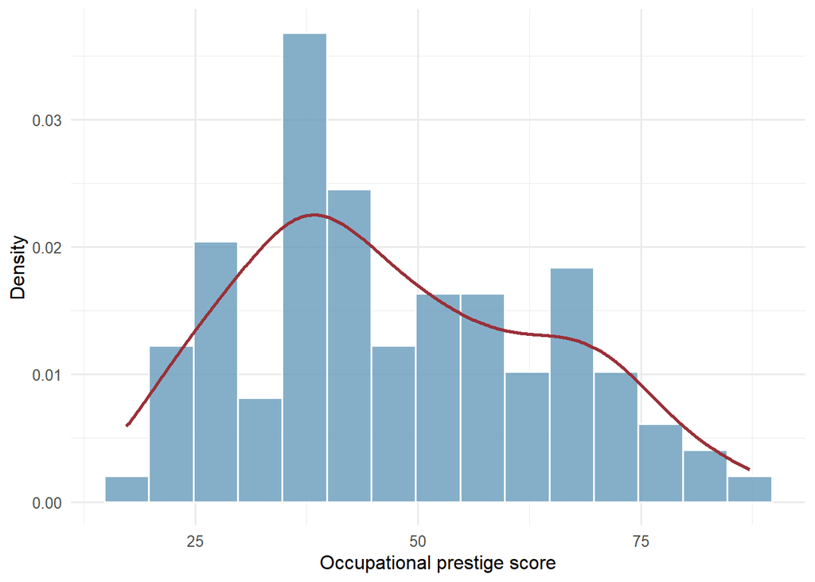

Distribution of occupational prestige scores

```r
ggplot(dat, aes(x = prestige)) +
  geom_histogram(
    aes(y = after_stat(density)),
    bins = 15,
    fill = "#669BBC",
    color = "white",
    alpha = 0.8
  ) +
  geom_density(
    linewidth = 0.9,
    color = "#9A3038"
  ) +
  labs(
    x = "Occupational prestige score",
    y = "Density"
  ) +
  theme_minimal(base_size = 12)
```

### Relationships between predictors and prestige

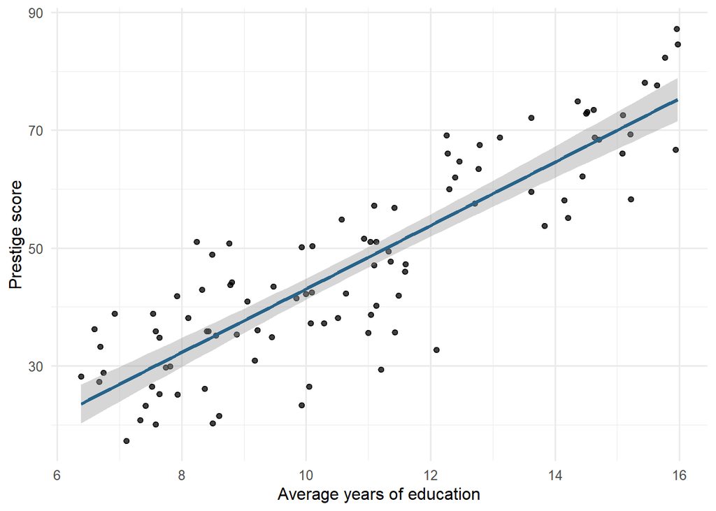

Relationship between education and occupational prestige

```r
ggplot(dat, aes(x = education, y = prestige)) +
  geom_point(alpha = 0.75) +
  geom_smooth(
    method = "lm",
    se = TRUE,
    color = "#27638A"
  ) +
  labs(
    x = "Average years of education",
    y = "Prestige score"
  ) +
  theme_minimal(base_size = 12)
```

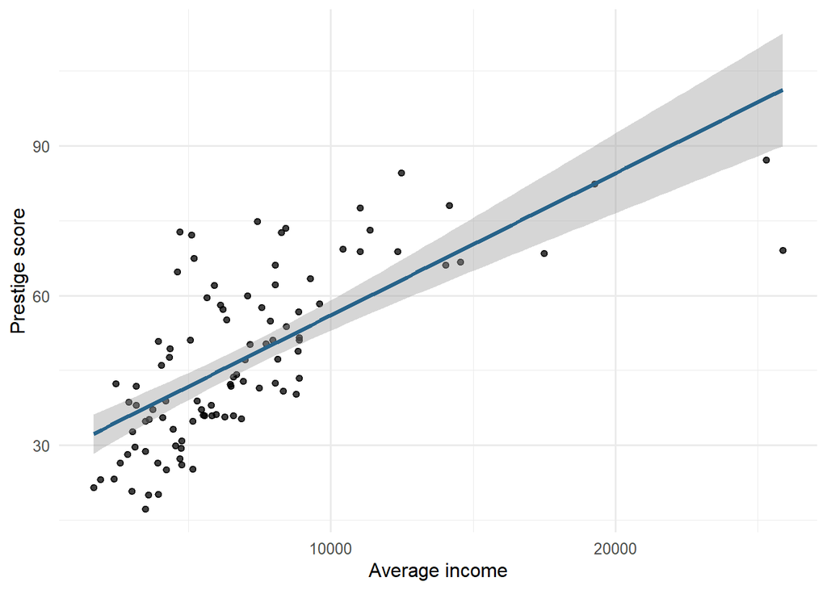

Relationship between income and occupational prestige

```r
ggplot(dat, aes(x = income, y = prestige)) +
  geom_point(alpha = 0.75) +
  geom_smooth(
    method = "lm",
    se = TRUE,
    color = "#27638A"
  ) +
  labs(
    x = "Average income",
    y = "Prestige score"
  ) +
  theme_minimal(base_size = 12)
```

These exploratory plots allow us to examine whether the relationships appear approximately linear and whether unusual observations may affect the regression analyses.

The regression lines shown here are bivariate relationships rather than relationships adjusted for other predictors.

## 3. Specify and estimate competing models

We will fit an intercept-only model and three increasingly complex substantive models.

| Model | Formula | Research rationale |
| --- | --- | --- |
| M0: Null | `prestige ~ 1` | Baseline model |
| M1: Education | `prestige ~ education` | Prestige varies with education |
| M2: Education + Income | `prestige ~ education + income` | Income explains additional variation |
| M3: Expanded | `prestige ~ education + income + type` | Occupational category explains additional variation |

The models are **nested**: each successive model contains all predictors from the preceding model, plus one or more additional predictors.

```r
# Intercept-only model
mod0 <- lm(prestige ~ 1, data = dat)

# Education model
mod1 <- lm(prestige ~ education, data = dat)

# Education + income model
mod2 <- lm(prestige ~ education + income, data = dat)

# Expanded model
mod3 <- lm(prestige ~ education + income + type, data = dat)
```

### Inspecting the models

After executing the model-fitting code, explore the results in the **R Console**:

```r
summary(mod0)
summary(mod1)
summary(mod2)
summary(mod3)

confint(mod3)
```

Some important interpretive distinctions:

- In M0, the intercept represents the sample mean prestige score.
- In M1, the education coefficient represents the expected difference in prestige associated with one additional year of average education.
- In M2, the education coefficient represents this association after adjusting for income.
- In M3, education and income coefficients are additionally adjusted for occupational category.

For categorical predictors, R uses a reference category by default.

Examine the coding using:

```r
levels(dat$type)
contrasts(dat$type)
```

## 4. Compare the models

We will evaluate the models using two complementary approaches.

**Nested-model F-tests** determine whether the additional predictor(s) in a larger model produce a statistically significant improvement in fit.

**Overall model performance** describes how well each model fits the observed data.

Our main performance metrics are:

- **R²:** Proportion of variation explained.
- **Adjusted R²:** Explained variation adjusted for model complexity.
- **RMSE:** Root mean squared error, expressed in prestige-score units.
- **ΔR²:** Increase in explained variation compared with the preceding model.

### 4.1. Conduct nested-model comparisons

Because our models are nested and estimated using the same observations, we can compare all four models in a single `anova()` call.

```r
tests <- anova(mod0, mod1, mod2, mod3)

tests
```

```
Analysis of Variance Table

Model 1: prestige ~ 1
Model 2: prestige ~ education
Model 3: prestige ~ education + income
Model 4: prestige ~ education + income + type
  Res.Df     RSS Df Sum of Sq        F    Pr(>F)
1     97 28346.9
2     96  7064.4  1   21282.5 422.8056 < 2.2e-16 ***
3     95  5272.4  1    1792.0  35.5999 4.355e-08 ***
4     93  4681.3  2     591.2   5.8721  0.003966 **
---
Signif. codes:  0 '***' 0.001 '**' 0.01 '*' 0.05 '.' 0.1 ' ' 1
```

Each row represents a model. The F-statistic and p-value on each row after the first test whether that model improves fit relative to the preceding model.

For example:

- M1 versus M0 tests the contribution of education.
- M2 versus M1 tests the additional contribution of income.
- M3 versus M2 tests the joint additional contribution of occupational category.

We can retain and rename the statistics relevant to our comparison table.

```r
tests <- tests |>
  select(Res.Df, Df, F, `Pr(>F)`) |>
  rename(
    Residual.df = Res.Df,
    Nested.Df = Df,
    Nested.F.stat = F,
    Nested.p.value = `Pr(>F)`
  )
```

### 4.2. Extract overall model performance

The `glance()` function returns a one-row data frame containing model-level statistics.

We can apply it to each fitted model.

```r
glance0 <- glance(mod0)
glance1 <- glance(mod1)
glance2 <- glance(mod2)
glance3 <- glance(mod3)
```

We can then combine these results using `rbind()`.

```r
mods <- c(
  "M0: Null",
  "M1: Education",
  "M2: + Income",
  "M3: + Type"
)

glances <- rbind(
  glance0,
  glance1,
  glance2,
  glance3
)
```

### 4.3. Combine nested tests and model performance

Because the rows in `glances` and `tests` represent the same models in the same order, we can combine them using `cbind()`.

```r
comparison_table <- cbind(
  Model = mods,
  glances,
  tests
)
```

Next, calculate the change in R² between successive models using `lag()`.

We will also calculate RMSE directly from each model’s residuals.

```r
comparison_table <- comparison_table |>
  mutate(
    Delta.R2 = r.squared - lag(r.squared),

    RMSE = c(
      sqrt(mean(residuals(mod0)^2)),
      sqrt(mean(residuals(mod1)^2)),
      sqrt(mean(residuals(mod2)^2)),
      sqrt(mean(residuals(mod3)^2))
    )
  ) |>
  select(
    Model,
    r.squared,
    Delta.R2,
    adj.r.squared,
    RMSE,
    Residual.df,
    Nested.Df,
    Nested.F.stat,
    Nested.p.value
  )
```

**Why calculate RMSE separately?**

Although `glance()` provides a statistic called `sigma`, this is the residual standard error rather than the ordinary in-sample RMSE. The two use different denominators.

For consistency, we calculate RMSE explicitly as the square root of the mean squared residual.

### 4.4. Display the combined model-comparison table

```r
comparison_table |>
  gt() |>
  cols_label(
    Model = "Model",
    r.squared = "R²",
    Delta.R2 = "ΔR²",
    adj.r.squared = "Adjusted R²",
    RMSE = "RMSE",
    Residual.df = "Residual df",
    Nested.Df = "Nested df",
    Nested.F.stat = "Nested F",
    Nested.p.value = "Nested p"
  ) |>
  fmt_number(
    columns = c(
      r.squared,
      Delta.R2,
      adj.r.squared,
      RMSE,
      Nested.F.stat
    ),
    decimals = 3
  ) |>
  fmt(
    columns = Nested.p.value,
    fns = function(x) {
      ifelse(
        is.na(x),
        "—",
        ifelse(x < .001, "< .001", sprintf("%.3f", x))
      )
    }
  ) |>
  sub_missing(
    columns = c(Delta.R2, Nested.Df, Nested.F.stat),
    missing_text = "—"
  )
```

Overall model performance and incremental nested-model comparisons

| Model | R² | ΔR² | Adjusted R² | RMSE | Residual df | Nested df | Nested F | Nested p |
| --- | --- | --- | --- | --- | --- | --- | --- | --- |
| M0: Null | 0.000 | — | 0.000 | 17.007 | 97 | — | — | — |
| M1: Education | 0.751 | 0.751 | 0.748 | 8.490 | 96 | 1 | 422.806 | < .001 |
| M2: + Income | 0.814 | 0.063 | 0.810 | 7.335 | 95 | 1 | 35.600 | < .001 |
| M3: + Type | 0.835 | 0.021 | 0.828 | 6.911 | 93 | 2 | 5.872 | 0.004 |

### Interpreting the combined table

Each row represents one fitted model.

The first set of statistics describes the **overall performance** of that model:

- R²
- Adjusted R²
- RMSE

The second set describes its **incremental improvement** relative to the preceding model:

- ΔR²
- Nested degrees of freedom
- Nested F-statistic
- Nested p-value

For example, the M2 row tells us:

1. How much variation M2 explains overall.
2. How much additional variation M2 explains compared with M1.
3. Whether the improvement is statistically significant.

The M3 comparison tests the joint contribution of occupational category after accounting for education and income.

The M0 row has no incremental comparison because it serves as the baseline.

### 4.5. Additional performance comparison

The `performance` package also provides a convenient way to compare fitted models.

```r
performance_comparison <- compare_performance(
  mod0,
  mod1,
  mod2,
  mod3,
  rank = TRUE
)
```

In the Console, inspect:

```r
performance_comparison
plot(performance_comparison)
```

These functions may include additional metrics such as AIC and BIC, which we will not focus on here.

## 5. Select a provisional model

Model selection requires considering both statistical evidence and model complexity.

In particular, we should consider:

1. Whether adding predictors significantly improves model fit.
2. How much additional variation is explained.
3. Whether adjusted R² improves.
4. Whether RMSE meaningfully decreases.
5. Whether the added complexity is substantively justified.

For this demonstration, we will use **adjusted R²** as an initial selection criterion.

This is a convenient teaching example, not a universal rule for selecting regression models.

```r
selected_row <- comparison_table |>
  slice_max(
    order_by = adj.r.squared,
    n = 1,
    with_ties = FALSE
  )

selected_name <- selected_row$Model

selected_model <- switch(
  selected_name,
  "M0: Null" = mod0,
  "M1: Education" = mod1,
  "M2: + Income" = mod2,
  "M3: + Type" = mod3
)
```

The provisionally selected model is **M3: + Type**.

Its performance is:

- R² = **0.835**
- Adjusted R² = **0.828**
- RMSE = **6.91** prestige points.

We will now examine whether the selected model has important diagnostic problems.

## 6. Evaluate regression diagnostics

Regression diagnostics help identify potential violations of model assumptions and unusual observations.

We will examine:

- Linearity.
- Residual normality.
- Heteroscedasticity.
- Influential observations.
- Multicollinearity, where applicable.

### Standard diagnostic plots

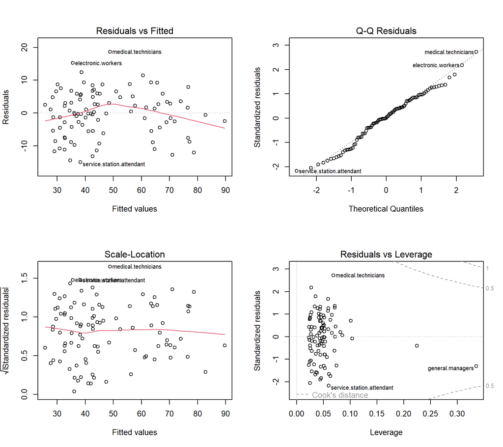

Regression diagnostic plots for the provisionally selected model

```r
op <- par(mfrow = c(2, 2))

plot(selected_model)
```

```r
par(op)
```

When interpreting these plots, consider:

**Residuals versus fitted values**

Is there evidence of curvature or systematic patterns?

**Normal Q–Q plot**

Do the residuals deviate substantially from a normal distribution?

**Scale–location plot**

Does residual variability change across fitted values?

**Residuals versus leverage**

Are there observations with unusually high leverage or influence?

### Additional diagnostics

The `performance` package provides a more comprehensive diagnostic interface.

Run the following interactively in the **Console**:

```r
check_model(selected_model)
```

For models with multiple predictors, you can also investigate multicollinearity:

```r
check_collinearity(selected_model)
```

These diagnostics should inform your final model selection.

A model with slightly better fit statistics may not be preferable if its assumptions are seriously compromised.

For the purposes of this worked example, we retain the provisionally selected model for the reporting demonstration.

## 7. Report the selected model

### 7.1. Extract regression coefficients

The `tidy()` function extracts coefficient-level results from a fitted model.

```r
coefficient_results <- tidy(
  selected_model,
  conf.int = TRUE,
  conf.level = 0.95
)
```

The resulting data frame contains:

- Coefficient estimates.
- Standard errors.
- Test statistics.
- p-values.
- Confidence interval limits.

### 7.2. Create a regression coefficient table

```r
coefficient_results |>
  select(
    term,
    estimate,
    std.error,
    conf.low,
    conf.high,
    p.value
  ) |>
  gt() |>
  cols_label(
    term = "Predictor",
    estimate = "Estimate",
    std.error = "SE",
    conf.low = "95% CI lower",
    conf.high = "95% CI upper",
    p.value = "p"
  ) |>
  fmt_number(
    columns = c(
      estimate,
      std.error,
      conf.low,
      conf.high
    ),
    decimals = 3
  ) |>
  fmt(
    columns = p.value,
    fns = function(x) {
      ifelse(
        x < .001,
        "< .001",
        sprintf("%.3f", x)
      )
    }
  )
```

Unstandardized regression coefficients for the selected model

| Predictor | Estimate | SE | 95% CI lower | 95% CI upper | p |
| --- | --- | --- | --- | --- | --- |
| (Intercept) | −0.623 | 5.228 | −11.004 | 9.758 | 0.905 |
| education | 3.673 | 0.641 | 2.401 | 4.945 | < .001 |
| income | 0.001 | 0.000 | 0.001 | 0.001 | < .001 |
| typeprof | 6.039 | 3.867 | −1.640 | 13.718 | 0.122 |
| typewc | −2.737 | 2.514 | −7.729 | 2.255 | 0.279 |

### 7.3. Report overall model performance

```r
selected_row |>
  select(
    Model,
    r.squared,
    adj.r.squared,
    RMSE
  ) |>
  gt() |>
  cols_label(
    Model = "Model",
    r.squared = "R²",
    adj.r.squared = "Adjusted R²",
    RMSE = "RMSE"
  ) |>
  fmt_number(
    columns = where(is.numeric),
    decimals = 3
  )
```

Overall performance of the selected model

| Model | R² | Adjusted R² | RMSE |
| --- | --- | --- | --- |
| M3: + Type | 0.835 | 0.828 | 6.911 |

## 8. Interpret the results

### Overall model performance

The selected model, **M3: + Type**, explains approximately **83.5%** of the variation in occupational prestige within this sample.

Its adjusted R² is **0.828**, and its in-sample RMSE is **6.91 prestige points**.

The RMSE describes the typical magnitude of the model’s fitted residuals on a root-mean-square scale.

It should not be interpreted as an estimate of out-of-sample predictive accuracy.

### Interpreting education

Holding the other predictors constant, a one-year increase in an occupation’s average education is associated with a significant **3.67-point** increase in predicted occupational prestige, 95% CI [2.4, 4.95].

### Interpreting income

Holding the other predictors constant, a one-unit increase in an occupation’s average income is associated with a significant **0.001-point** increase in predicted occupational prestige, 95% CI [0.001, 0.001].

### Interpreting occupational category

If the selected model includes `type`, its coefficients represent differences in predicted prestige relative to the reference occupational category, holding constant education and income.

These are adjusted group differences, not differences between the raw category means.

### Substantive conclusions

This analysis illustrates how occupational prestige can be investigated using several competing regression models.

The model-comparison process allows us to evaluate whether additional predictors explain meaningful variation beyond simpler models.

The final model provides estimates of the conditional associations between occupational characteristics and prestige.

However, several limitations should be recognized:

- The observations describe occupations rather than individual people.
- The data are observational.
- Regression coefficients represent associations rather than causal effects.
- Model diagnostics may reveal limitations not captured by summary fit statistics.
- In-sample model performance does not establish out-of-sample predictive accuracy.